# *Regression: Supervised Machine Learning*

### *Where to use which Metric to determine the Performance of a Machine Learning Model?*

*MAE:* *It is not very sensitive to outliers in comparison to MSE since it doesn't punish huge errors. It is usually used when the performance is measured on continuous variable data. It gives a linear value, which averages the weighted individual differences equally. The lower the value, better is the model's performance. MAE does not indicate underperformance or overperformance of the model.*

*MSE:* *It is one of the most commonly used metrics, but least useful when a single bad prediction would ruin the entire model's predicting abilities, i.e when the dataset contains a lot of noise. It is most useful when the dataset contains outliers, or unexpected values (too high or too low values).*

*RMSE:* *In RMSE, the errors are squared before they are averaged. This basically implies that RMSE assigns a higher weight to larger errors. This indicates that RMSE is much more useful when large errors are present and they drastically affect the model's performance. It avoids taking the absolute value of the error and this trait is useful in many mathematical calculations. In this metric also, lower the value, better is the performance of the model.*

```python
print("R-squared value of predictions:",round(r2_score(y_test,y_pred),3))
print("Mean absolute error (MAE):", mean_absolute_error(y_test,y_pred))
print("Mean square error (MSE):", mean_squared_error(y_test,y_pred))
print("Root mean square error (RMSE):", np.sqrt(mean_squared_error(y_test,y_pred)))
```

```
R-squared value of predictions: 0.919
Mean absolute error (MAE): 81739.77482718245
Mean square error (MSE): 10489638335.805471
Root mean square error (RMSE): 102418.93543581417
```

### *Actual vs Predicted Plot*

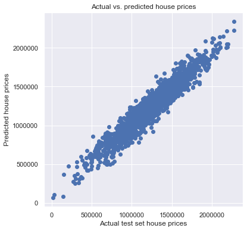

```python
# Actuals Vs Predicted

plt.figure(figsize=(6,6))
plt.title("Actual vs. predicted house prices")
plt.xlabel("Actual test set house prices")
plt.ylabel("Predicted house prices")
plt.scatter(x=y_test,y=y_pred)
```

### *Residuals Plot*

[figure not shown]

```python
# histogram of the residuals i.e. predicted errors (expect a normally distributed pattern)
# Assumption No. 4
plt.figure(figsize=(6,6))
plt.title("Histogram of Residuals (Normality Check)")
plt.xlabel("Residuals")
plt.ylabel("Kernel density")
sns.distplot(residuals)
```

### *Heteroscedasticity Tests*

*[Test Details](https://medium.com/@remycanario17/tests-for-heteroskedasticity-in-python-208a0fdb04ab)*

*The null hypothesis for this test is that the error variances are all equal.*

*The alternate hypothesis is that the error variances are not equal. More specifically, as Y increases, the variances increase (or decrease).*

```python
from statsmodels.stats.diagnostic import het_breuschpagan
```

```python
name = ['Lagrange multiplier statistic', 'p-value', 'f-value', 'f p-value']
test = het_breuschpagan(results.resid, results.model.exog)
print(dict(zip(name, test)))
```

```
{'Lagrange multiplier statistic': 1150.0855185049165, 'p-value': 1.0533131842013223e-247, 'f-value': 342.1017163669149, 'f p-value': 4.685681562849976e-299}
```

### *Residual vs Predicted Plot*

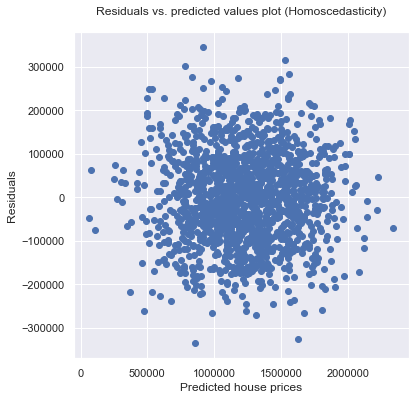

```python
# Spread of Error wrt predictions

plt.figure(figsize=(6,6))
plt.title("Residuals vs. predicted values plot (Homoscedasticity)\n")
plt.xlabel("Predicted house prices")
plt.ylabel("Residuals")
plt.scatter(x=y_pred,y=residuals)
```

### *QQ Plot*

*To check distribution of Error wrt to a normal distribution.*

```python
# QQ PLot
from statsmodels.graphics.gofplots import qqplot
```

```python
plt.figure(figsize=(6,6))
fig=qqplot(residuals,line='45',fit='True')
plt.xlabel("Theoretical quantiles")
plt.ylabel("Sample quantiles")
plt.title("Q-Q plot of normalized residuals")
plt.show()
```

[output not shown]

### *Error Normality Test*

```python
# Normality (Shapiro-Wilk) test of the residuals

from scipy.stats import shapiro

_,p=shapiro(residuals)

if p<0.05:
    print("The residuals seem to come from Gaussian process")
else:
    print("The normality assumption may not hold")
```

```
The normality assumption may not hold
```

### *Cook's Distance*

*Cook’s Distance is a measure of an observation or instances’ influence on a linear regression. Instances with a large influence may be outliers and datasets that have a large number of highly influential points might not be good predictors to fit linear models.*

*Outliers:* *In linear regression, an outlier is an observation with large residual.* *In other words, it is an observation whose dependent-variable value is unusual given its values on the predictor variables.* *An outlier may indicate a sample peculiarity or may indicate a data entry error or other problem.*

*Leverage:* *An observation with an extreme value on a predictor variable is called a point with high leverage.* *Leverage is a measure of how far an observation deviates from the mean of that variable.* *These leverage points can have an effect on the estimate of regression coefficients.*

*Influence:* *An observation is said to be influential if removing the observation substantially changes the estimate of coefficients.* *Influence can be thought of as the product of leverage and outlierness.*

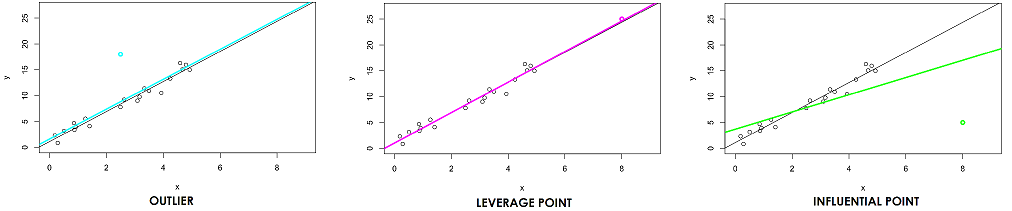

_[Very Good Video](https://www.youtube.com/watch?v=xc_X9GFVuVU)_

```python
influ = results.get_influence()
influ.summary_frame()

# dffits measure for influence of an observation
# cook's distance
```

|  | dfb_Avg. Area Income | dfb_Avg. Area House Age | dfb_Avg. Area Number of Rooms | dfb_Avg. Area Number of Bedrooms | dfb_Area Population | cooks_d | standard_resid | hat_diag | dffits_internal | student_resid | dffits |
| --- | --- | --- | --- | --- | --- | --- | --- | --- | --- | --- | --- |
| 4036 | 0.001688 | 0.006796 | -0.005149 | 0.010057 | -0.010591 | 0.000071 | 0.566680 | 0.001097 | 0.018778 | 0.566625 | 0.018776 |
| 2883 | 0.006378 | -0.018482 | -0.009975 | 0.025426 | 0.005098 | 0.000258 | -1.235654 | 0.000845 | -0.035943 | -1.235748 | -0.035946 |
| 4162 | 0.003218 | -0.010651 | 0.007319 | -0.016171 | 0.018371 | 0.000184 | 0.821478 | 0.001364 | 0.030357 | 0.821439 | 0.030356 |
| 4640 | -0.004255 | -0.012060 | 0.058034 | -0.049113 | -0.028536 | 0.000963 | 1.368197 | 0.002567 | 0.069408 | 1.368368 | 0.069416 |
| 2430 | -0.015780 | 0.009321 | -0.009284 | 0.030315 | 0.001505 | 0.000289 | 0.919712 | 0.001706 | 0.038025 | 0.919692 | 0.038024 |
| ... | ... | ... | ... | ... | ... | ... | ... | ... | ... | ... | ... |
| 1593 | 0.000297 | -0.004243 | 0.004279 | -0.013126 | 0.009045 | 0.000069 | -0.476134 | 0.001529 | -0.018635 | -0.476081 | -0.018633 |
| 4060 | 0.002265 | 0.008799 | -0.005735 | -0.005314 | -0.002592 | 0.000048 | -0.492610 | 0.000983 | -0.015454 | -0.492557 | -0.015452 |
| 1346 | 0.019024 | -0.001461 | -0.011594 | 0.002966 | -0.010706 | 0.000108 | -0.486214 | 0.002280 | -0.023244 | -0.486161 | -0.023241 |
| 3454 | -0.005939 | -0.018889 | 0.024834 | -0.004349 | -0.010040 | 0.000208 | -0.821875 | 0.001540 | -0.032282 | -0.821837 | -0.032280 |
| 3582 | 0.001102 | -0.002116 | 0.002711 | -0.001591 | 0.000275 | 0.000016 | 0.476664 | 0.000346 | 0.008869 | 0.476612 | 0.008868 |

3500 rows × 11 columns

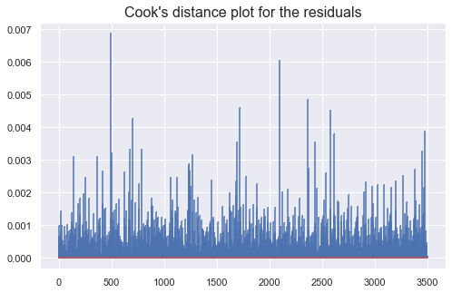

```python
# Cook's distance (checking for outliers in residuals (that have a distance greater than 0.5))
from statsmodels.stats.outliers_influence import OLSInfluence as influence
inf=influence(results)

(c, p) = inf.cooks_distance

plt.figure(figsize=(8,5))
plt.title("Cook's distance plot for the residuals",fontsize=16)
plt.stem(np.arange(len(c)), c, markerfmt=",")
plt.grid(True)
plt.show()
```

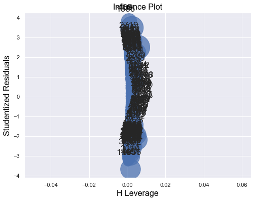

```python
# Influential Point

from statsmodels.graphics.regressionplots import influence_plot

fig, ax = plt.subplots(figsize=(8,6))
fig = influence_plot(results, ax = ax)
```

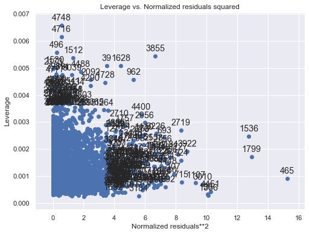

```python
from statsmodels.graphics.regressionplots import plot_leverage_resid2

fig, ax = plt.subplots(figsize=(8,6))
fig = plot_leverage_resid2(results, ax = ax)
```

### *Variance Inflation Factor*

```python
from statsmodels.stats.outliers_influence import variance_inflation_factor as vif
```

```python
data = pd.concat([X,Y],axis =1)

for i in range(len(data.columns[:-1])):
    v=vif(np.matrix(data[:-1]),i)
    print("Variance inflation factor for {}: {}".format(data.columns[i],round(v,2)))
```

[output not shown]

*VIF value <= 4 suggests no multicollinearity whereas a value of >= 10 implies serious multicollinearity.*

## *Advantages of Using Linear Regression*

- *Linear Regression method is very easy to use. If the relationship between the variables (independent and dependent) is known, we can easily implement the regression method accordingly (Linear Regression for linear relationship).*
- *Linear Regression provides the significance level of each attribute contributing to the prediction of the dependent variable. With this data, we can choose between the variables which are highly contributing/ important variables.*
- *After performing linear regression we get the best fit line, which is used in prediction, which we can use according to the business requirement.*

## *Limitations of Linear Regression*

- *The main limitation of linear regression is that its performance is not up to the mark in the case of a nonlinear relationship. Linear regression can be affected by the presence of outliers in the dataset. The presence of high correlation among the variables also leads to the poor performance of the linear regression model.*

## *Polynomial Regression*

*Polynomial regression is a form of regression analysis in which the relationship between the independent variable x and the dependent variable y is modelled as an nth degree polynomial in x.*

*Polynomial regression fits a nonlinear relationship between the value of x and the corresponding conditional mean of y, Although polynomial regression fits a nonlinear model to the data, as a statistical estimation problem it is linear, in the sense that the regression function E(y | x) is linear in the unknown parameters that are estimated from the data. For this reason, polynomial regression is considered to be a **special case of multiple linear regression.***

*Conveniently, these models are all linear from the point of view of estimation, since the regression function is linear in terms of the unknown parameters β0, β1, .... Therefore, for least squares analysis, the computational and inferential problems of polynomial regression can be completely addressed using the techniques of multiple regression. This is done by treating x, x2, ... as being distinct independent variables in a multiple regression mode.*

*The polynomial regression model*

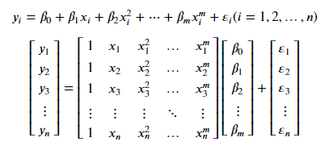

*Polynomial regression describe nonlinear phenomena such as the growth rate of tissues,the distribution of carbon isotopes in lake sediments, and the progression of disease epidemics.*

### *Understanding why Polynomial Regression?*

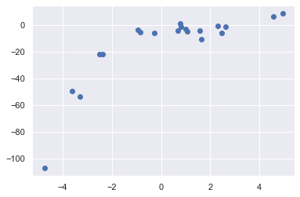

```python
np.random.seed(0)
plt.figure(figsize = (6,4))
#x = 2-3*np.random.normal(0,1,20)  # 0 mean 1 standard deviation with 20 values
#y = (x ** 3) + np.random.normal(5, 5, 20) # to create quadratic curve use x^3 function which does not plot a linear line
x = 2 - 3 * np.random.normal(0, 1, 20)
y = x - 2 * (x ** 2) + 0.5 * (x ** 3) + np.random.normal(-3, 3, 20)
plt.scatter(x,y)
plt.show()
```

```python
# transforming the data to include new axis
x = x[:,np.newaxis]  # (20,1)
y = y.reshape(-1 , 1) # (20,1)
```

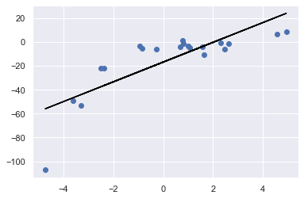

```python
model = LinearRegression()
model.fit(x,y)
y_pred = model.predict(x)

plt.figure(figsize = (6,4))
plt.scatter(x,y)
plt.plot(x,y_pred,c = 'black')
plt.show()
```

```python
r2 = r2_score(y,y_pred)
rmse = mean_squared_error(y,y_pred)
print('R square value is :',r2)  # it should be maximum as possible towards 1
print('Root mean square value is :',np.sqrt(rmse))  # it should be minimum as possible towards 0
```

```
R square value is : 0.6386750054827146
Root mean square value is : 15.908242501429998
```

*Now, We can see that the new fitting line is not passing through aleast 70% of data. This is the example of UnderFitting to overcome the underfitting we need to increase the complexity of the model.*

*This is still considered to be linear model as the coefficients associated with the features are still linear. x² is only a feature. However the curve that we are fitting is quadratic in nature.*

```python
def poly(deg):
    global x,y
    import operator
    from sklearn.preprocessing import PolynomialFeatures

    polynomial_feature = PolynomialFeatures(degree = deg)
    x_poly = polynomial_feature.fit_transform(x)
    #print(x_poly)  # 20,3

    model = LinearRegression()
    model.fit(x_poly , y)
    y_poly_pred = model.predict(x_poly)

    rmse_1 = np.sqrt(mean_squared_error(y,y_poly_pred))
    r2_1 = r2_score(y,y_poly_pred)
    print('R square value is :',r2_1)  # it should be maximum as possible towards 1
    print('Root mean square value is :',(rmse_1))  # it should be minimum as possible towards 0

    plt.figure(figsize = (6,4))
    plt.scatter(x, y, s=10)
    sort_axis = operator.itemgetter(0)
    sorted_zip = sorted(zip(x,y_poly_pred), key=sort_axis)
    x_, y_poly_pred = zip(*sorted_zip)
    plt.plot(x_, y_poly_pred, color='m')
    plt.show()
```

```
R square value is : 0.8537647164420812
Root mean square value is : 10.120437473614711
```

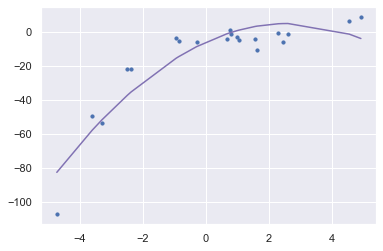

```python
poly(2)
```

```
R square value is : 0.9941487971704481
Root mean square value is : 2.024397427560471
```

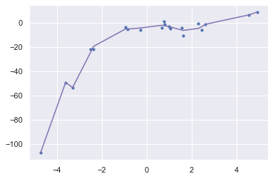

```python
poly(10)
```

### *Model using sklearn*

```python
temprature = [0,20,40,60,80,100]
pressure = [0.0002,0.0012,0.0060,0.0300,0.0900,0.2700]

data = pd.DataFrame(list(zip(temprature,pressure)), columns= ['Temp', 'Pressure'])
data
```

|  | Temp | Pressure |
| --- | --- | --- |
| 0 | 0 | 0.0002 |
| 1 | 20 | 0.0012 |
| 2 | 40 | 0.0060 |
| 3 | 60 | 0.0300 |
| 4 | 80 | 0.0900 |
| 5 | 100 | 0.2700 |

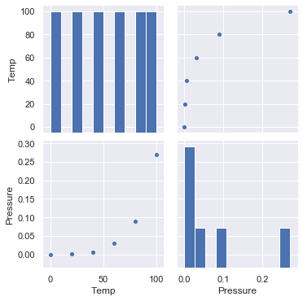

```python
sns.pairplot(data)
```

```python
X = data.iloc[:, 0].values.reshape(-1, 1)
Y = data.iloc[:, 1].values

from sklearn.preprocessing import PolynomialFeatures

poly = PolynomialFeatures(degree=4)
X_poly = poly.fit_transform(X)
```

```python
lr = LinearRegression()
lr.fit(X_poly, Y)
```

```
LinearRegression()
```

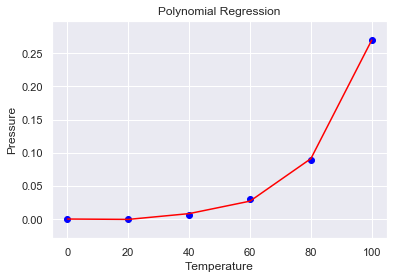

```python
# Visualising the Polynomial Regression results
plt.figure(figsize = (6,4))
plt.scatter(X, Y, color = 'blue')
plt.plot(X, lr.predict(X_poly), color = 'red')
plt.title('Polynomial Regression')
plt.xlabel('Temperature')
plt.ylabel('Pressure')
plt.show()
```

# *Regularization*

*Regularization helps to solve over fitting problem in machine learning. Simple model will be a very poor generalization of data. At the same time, complex model may not perform well in test data due to over fitting. We need to choose the right model in between simple and complex model. Regularization helps to choose preferred model complexity, so that model is better at predicting. Regularization is nothing but adding a penalty term to the objective function and control the model complexity using that penalty term. It can be used for many machine learning algorithms.*

- *Regularization is a method for “constraining” or “regularizing” the size of the coefficients, thus “shrinking” them towards zero.*
- _It *reduces model variance* and thus *minimizes overfitting*._
- _If the model is too complex, it tends to reduce variance more than it increases bias, resulting in a model that is more likely to *generalize*._

### *What is overfitting?*

- *Building a model that matches the training data “too closely”.*
- *Learning from the error/distrubance/noise in the data, rather than just the truevalues/signal.*

### *How does over-fitting occur?*

- *Evaluating a model by testing it on the same data that was used to train it.*
- *Creating a model that is “too complex”.*

### *What is the impact of over-fitting?*

- *Model will do well on the training data, but won’t generalize to out-of-sample data i.e., test*
- *Model will have low bias, but high variance.*

### *Cause of Overfitting*

- *Irrelevant features*
- *Correlated features(Multicollinearity)*
- *Large coefficients - as this will give more power to that feature.*

### *How does regularization work?*

*For a normal linear regression model, we estimate the coefficients using the least squares criterion, which minimizes the residual sum of squares (RSS):*

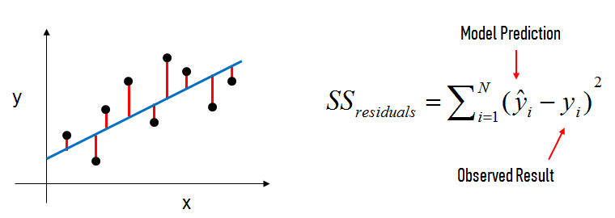

_For a regularized linear regression model, we *minimize the sum of RSS and a “penalty term” that penalizes coefficient size*._

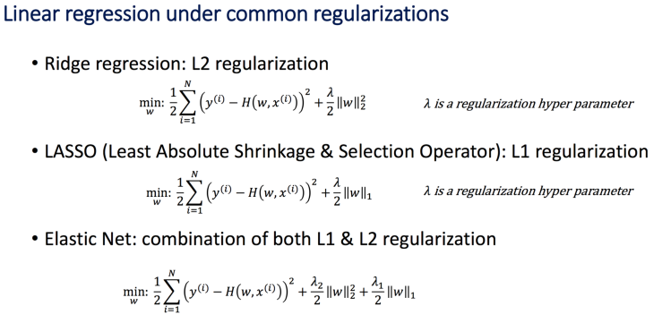

### *Lasso - L1 Regularization*

- *Lasso stands for Least Absolute Shrinkage Selector Operator.*
- *Lasso assigns a penalty to the coefficients in the linear model using the formula below and eliminates variables with coefficients that zero.*
- *This is called shrinkage or the process where data values are shrunk to a central point such as a mean.*
- *Looking at the formula, Lasso adds a penalty equal to the absolute value of the magnitude of the coefficients multiplied by lambda.*
- *The value of lambda also plays a key role in how much weight you assign to the penalty for the coefficients.*
  - *As λ increases, bias increases.*
  - *As λ decreases, variance increases.*
- *This penalty reduces the value of many coefficients to zero, all of which are eliminated.*
- *Lasso can also be used for Feature Selection.*
- *It is robust to outliers.*
- *L1 generates model that are simple and interpretable but cannot learn complex patterns.*

#### *What is the significance of adding a penalty to coefficients in lasso?*

- *Lasso adds a penalty to coefficients the model overemphasizes.*
- *This reduces the degree of overfitting that occurs within the model.*

#### *What are some limitations of the Lasso model?*

- *Lasso does not work well with multicollinearity. Why? Lasso might randomly choose one of the multicollinear variables without understanding the context. Such an action might eliminate relevant independent variables.*

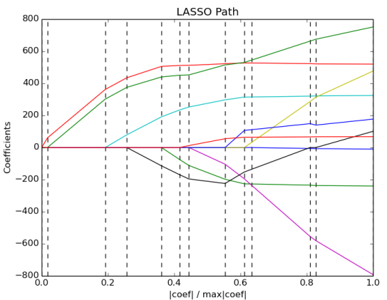

### *Ridge - L2 Regularization*

- *Ridge assigns a penalty that is the squared magnitude of the coefficients to the loss function multiplied by lambda.*
- *As Lasso does, ridge also adds a penalty to coefficients the model overemphasizes.*
- *The value of lambda also plays a key role in how much weight you assign to the penalty for the coefficients.*
- *The larger your value of lambda, the more likely your coefficients get closer and closer to zero.*
- *Unlike lasso, the ridge model will not shrink these coefficients to zero.*
- *It is not robust to outliers.*
- *L2 regularization is able to learn complex data patterns.*

#### *What are some limitations of Ridge?*

- *Ridge does not eliminate coefficients in your model even if the variables are irrelevant.*
- *This can be negative if you have more features than observations.*

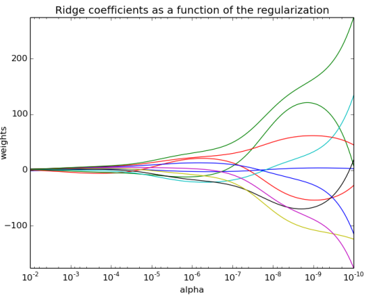

### *Elastic Net*

- *Elastic Net combines characteristics of both lasso and ridge.*
- *Elastic Net reduces the impact of different features while not eliminating all of the features.*

### *How should we choose between Lasso regression and Ridge regression?*

- *Lasso regression is preferred if we believe many features are irrelevant or if we prefer a sparse model.*
- *If model performance is your primary concern, it is best to try both.*
- *Elastic-Net regression is a combination of lasso regression and ridge Regression.*

### *Should features be standardized?*

- *Yes, because otherwise, features would be penalized simply because of their scale.*
- *Also, standardizing avoids penalizing the intercept, which wouldn’t make intuitive sense.*

### *Visualizing regularization*

*Below is a visualization of what happens when you apply regularization. The general idea is that you are restricting the allowed values of your coefficients to a certain “region”. Within that region, you want to find the coefficients that result in the best model.*

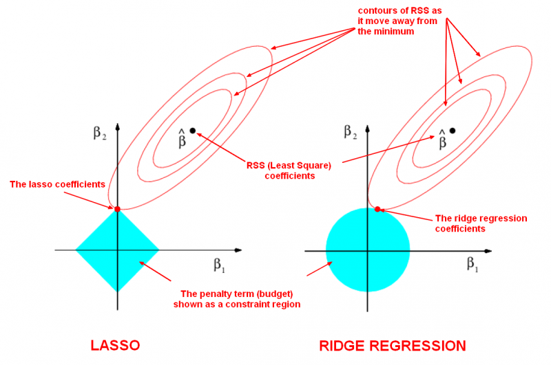

*In this diagram:*

- *We are fitting a linear regression model with two features, 𝑥1 and 𝑥2.*
- *𝛽̂ represents the set of two coefficients, 𝛽1 and 𝛽2, which minimize the RSS for the unregularized model.*
- *Regularization restricts the allowed positions of 𝛽̂ to the blue constraint region:*
- *For lasso, this region is a diamond because it constrains the absolute value of the coefficients.*
- *For ridge, this region is a circle because it constrains the square of the coefficients.*
- *The size of the blue region is determined by 𝛼, with a smaller 𝛼 resulting in a larger region:*
- *When 𝛼 is zero, the blue region is infinitely large, and thus the coefficient sizes are not constrained.*
- *When 𝛼 increases, the blue region gets smaller and smaller.*

*In this case, 𝛽̂ is not within the blue constraint region. Thus, we need to move 𝛽̂ until it intersects the blue region, while increasing the RSS as little as possible.*

```python
# Regularization of Linear Models
from sklearn.linear_model import Ridge, Lasso, ElasticNet
from sklearn.datasets import load_boston
```

```python
boston=load_boston()
boston_df=pd.DataFrame(boston.data,columns=boston.feature_names)
boston_df.head()
```

|  | CRIM | ZN | INDUS | CHAS | NOX | RM | AGE | DIS | RAD | TAX | PTRATIO | B | LSTAT |
| --- | --- | --- | --- | --- | --- | --- | --- | --- | --- | --- | --- | --- | --- |
| 0 | 0.00632 | 18.0 | 2.31 | 0.0 | 0.538 | 6.575 | 65.2 | 4.0900 | 1.0 | 296.0 | 15.3 | 396.90 | 4.98 |
| 1 | 0.02731 | 0.0 | 7.07 | 0.0 | 0.469 | 6.421 | 78.9 | 4.9671 | 2.0 | 242.0 | 17.8 | 396.90 | 9.14 |
| 2 | 0.02729 | 0.0 | 7.07 | 0.0 | 0.469 | 7.185 | 61.1 | 4.9671 | 2.0 | 242.0 | 17.8 | 392.83 | 4.03 |
| 3 | 0.03237 | 0.0 | 2.18 | 0.0 | 0.458 | 6.998 | 45.8 | 6.0622 | 3.0 | 222.0 | 18.7 | 394.63 | 2.94 |
| 4 | 0.06905 | 0.0 | 2.18 | 0.0 | 0.458 | 7.147 | 54.2 | 6.0622 | 3.0 | 222.0 | 18.7 | 396.90 | 5.33 |

```python
boston_df['Price']=boston.target
print(boston_df.head(3))
```

```
      CRIM    ZN  INDUS  CHAS    NOX     RM   AGE     DIS  RAD    TAX  \
0  0.00632  18.0   2.31   0.0  0.538  6.575  65.2  4.0900  1.0  296.0
1  0.02731   0.0   7.07   0.0  0.469  6.421  78.9  4.9671  2.0  242.0
2  0.02729   0.0   7.07   0.0  0.469  7.185  61.1  4.9671  2.0  242.0

   PTRATIO       B  LSTAT  Price
0     15.3  396.90   4.98   24.0
1     17.8  396.90   9.14   21.6
2     17.8  392.83   4.03   34.7
```

```python
Features = boston_df.drop('Price',axis=1)
Target = boston_df['Price']
```

```python
X_train,X_test,y_train,y_test = train_test_split(Features, Target, test_size = 0.2)
```

```python
lm = LinearRegression().fit(X_train,y_train)
```

```python
lm.coef_
```

```
array([-0.118582, 0.054139, -0.018202, 4.184634, -16.942009, 4.026792,
       0.004221, -1.618167, 0.299842, -0.011038, -0.891923, 0.009626,
       -0.551032])
```

```python
lm.intercept_
```

```
33.84727084187719
```

```python
prediction = lm.predict(X_test)
```

```python
pd.DataFrame({"Actuals":y_test,
             "Prediction":prediction,
             "Residuals":y_test-prediction})
```

|  | Actuals | Prediction | Residuals |
| --- | --- | --- | --- |
| 405 | 5.0 | 7.593831 | -2.593831 |
| 331 | 17.1 | 19.372299 | -2.272299 |
| 382 | 11.3 | 13.370450 | -2.070450 |
| 393 | 13.8 | 20.471802 | -6.671802 |
| 392 | 9.7 | 9.607927 | 0.092073 |
| ... | ... | ... | ... |
| 307 | 28.2 | 33.226144 | -5.026144 |
| 485 | 21.2 | 22.121072 | -0.921072 |
| 79 | 20.3 | 21.947305 | -1.647305 |
| 38 | 24.7 | 22.689611 | 2.010389 |
| 274 | 32.4 | 37.828014 | -5.428014 |

102 rows × 3 columns

```python
# Score on TRAIN Data
lm.score(X_train,y_train)
```

```
0.7548085948299021
```

```python
# Score on TEST Data
lm.score(X_test,y_test)
```

```
0.6470000403936065
```

```python
print("R-squared value of predictions:",round(r2_score(y_test,prediction),3))
print("Mean absolute error (MAE):", mean_absolute_error(y_test,prediction))
print("Mean square error (MSE):", mean_squared_error(y_test,prediction))
print("Root mean square error (RMSE):", np.sqrt(mean_squared_error(y_test,prediction)))
```

```
R-squared value of predictions: 0.647
Mean absolute error (MAE): 3.2363819973344516
Mean square error (MSE): 26.112153794967565
Root mean square error (RMSE): 5.110005263692745
```

- _If Train Score is More then Test Score we can called it as *Overfitting*._
- _If Train Score is less and Test Score is More then it is called *Underfitting*._

```python
# Cross-Validation

r2 = make_scorer(r2_score)
CV = cross_val_score(lm, X_train, y_train, cv=10, scoring=r2)
print('Mean CV Score:',round(CV.mean()*100,2))
```

```
Mean CV Score: 68.87
```

```python
round(np.min(CV)*100,2)
```

```
47.28
```

```python
round(np.max(CV)*100,2)
```

```
80.09
```

### *Ridge Model*

```python
# Ridge Model
ridge = Ridge(alpha = 0.01)
```

```python
ridge.fit(X_train, y_train)
```

```
Ridge(alpha=0.01)
```

```python
ridge.coef_
```

```
array([-0.118504, 0.054161, -0.018800, 4.181405, -16.805342, 4.027916,
       0.004089, -1.616274, 0.299490, -0.011046, -0.890371, 0.009630,
       -0.551214])
```

```python
ridge.intercept_
```

```
33.7513236121511
```

```python
prediction = ridge.predict(X_test)
```

```python
pd.DataFrame({"Actuals":y_test,
             "Prediction":prediction,
             "Residuals":y_test-prediction})
```

|  | Actuals | Prediction | Residuals |
| --- | --- | --- | --- |
| 405 | 5.0 | 7.597998 | -2.597998 |
| 331 | 17.1 | 19.371491 | -2.271491 |
| 382 | 11.3 | 13.371074 | -2.071074 |
| 393 | 13.8 | 20.475071 | -6.675071 |
| 392 | 9.7 | 9.608549 | 0.091451 |
| ... | ... | ... | ... |
| 307 | 28.2 | 33.223311 | -5.023311 |
| 485 | 21.2 | 22.119363 | -0.919363 |
| 79 | 20.3 | 21.937876 | -1.637876 |
| 38 | 24.7 | 22.694036 | 2.005964 |
| 274 | 32.4 | 37.822936 | -5.422936 |

102 rows × 3 columns

```python
# Score on TRAIN Data
ridge.score(X_train,y_train)
```

```
0.7548079339261369
```

```python
ridge.score(X_test,y_test)
```

```
0.6469792043369558
```

```python
print("R-squared value of predictions:",round(r2_score(y_test,prediction),3))
print("Mean absolute error (MAE):", mean_absolute_error(y_test,prediction))
print("Mean square error (MSE):", mean_squared_error(y_test,prediction))
print("Root mean square error (RMSE):", np.sqrt(mean_squared_error(y_test,prediction)))
```

```
R-squared value of predictions: 0.647
Mean absolute error (MAE): 3.2360655258119495
Mean square error (MSE): 26.11369508215737
Root mean square error (RMSE): 5.110156072191668
```

### *Lasso Model*

```python
lasso = Lasso(alpha = 0.01)
```

```python
lasso.fit(X_train, y_train)
```

```
Lasso(alpha=0.01)
```

```python
lasso.coef_
```

```
array([-0.116441, 0.054653, -0.031403, 3.982797, -13.584356, 4.034231,
       0.001380, -1.566699, 0.291739, -0.011298, -0.855103, 0.009742,
       -0.557263])
```

```python
lasso.intercept_
```

```
31.625802276253857
```

```python
prediction = lasso.predict(X_test)
```

```python
pd.DataFrame({"Actuals":y_test,
             "Prediction":prediction,
             "Residuals":y_test-prediction})
```

|  | Actuals | Prediction | Residuals |
| --- | --- | --- | --- |
| 405 | 5.0 | 7.714669 | -2.714669 |
| 331 | 17.1 | 19.366027 | -2.266027 |
| 382 | 11.3 | 13.393427 | -2.093427 |
| 393 | 13.8 | 20.559403 | -6.759403 |
| 392 | 9.7 | 9.637622 | 0.062378 |
| ... | ... | ... | ... |
| 307 | 28.2 | 33.154908 | -4.954908 |
| 485 | 21.2 | 22.086069 | -0.886069 |
| 79 | 20.3 | 21.729043 | -1.429043 |
| 38 | 24.7 | 22.798212 | 1.901788 |
| 274 | 32.4 | 37.581825 | -5.181825 |

102 rows × 3 columns

```python
# Score on TRAIN Data
lasso.score(X_train,y_train)
```

```
0.7543886710064132
```

```python
lasso.score(X_test,y_test)
```

```
0.6480273626616343
```

```python
print("R-squared value of predictions:",round(r2_score(y_test,prediction),3))
print("Mean absolute error (MAE):", mean_absolute_error(y_test,prediction))
print("Mean square error (MSE):", mean_squared_error(y_test,prediction))
print("Root mean square error (RMSE):", np.sqrt(mean_squared_error(y_test,prediction)))
```

```
R-squared value of predictions: 0.648
Mean absolute error (MAE): 3.2248253353215817
Mean square error (MSE): 26.03616059346791
Root mean square error (RMSE): 5.102564119486193
```

### *Elastic Net Model*

```python
enet = ElasticNet()
```

```python
enet.fit(X_train,y_train)
```

```
ElasticNet()
```

```python
enet.coef_
```

```
array([-0.086321, 0.061144, -0.053802, 0.000000, -0.000000, 1.034769,
       0.028562, -0.914217, 0.295294, -0.014621, -0.757423, 0.008697,
       -0.799089])
```

```python
enet.intercept_
```

```
41.883283749999705
```

```python
prediction = enet.predict(X_test)
```

```python
pd.DataFrame({"Actuals":y_test,
             "Prediction":prediction,
             "Residuals":y_test-prediction})
```

|  | Actuals | Prediction | Residuals |
| --- | --- | --- | --- |
| 405 | 5.0 | 9.514809 | -4.514809 |
| 331 | 17.1 | 20.881796 | -3.781796 |
| 382 | 11.3 | 13.899265 | -2.599265 |
| 393 | 13.8 | 20.958162 | -7.158162 |
| 392 | 9.7 | 11.254373 | -1.554373 |
| ... | ... | ... | ... |
| 307 | 28.2 | 32.284315 | -4.084315 |
| 485 | 21.2 | 21.932018 | -0.732018 |
| 79 | 20.3 | 21.859490 | -1.559490 |
| 38 | 24.7 | 23.247991 | 1.452009 |
| 274 | 32.4 | 32.952160 | -0.552160 |

102 rows × 3 columns

```python
# Score on TRAIN Data
enet.score(X_train,y_train)
```

```
0.6932854854913482
```

```python
enet.score(X_test,y_test)
```

```
0.6726718403554044
```

```python
print("R-squared value of predictions:",round(r2_score(y_test,prediction),3))
print("Mean absolute error (MAE):", mean_absolute_error(y_test,prediction))
print("Mean square error (MSE):", mean_squared_error(y_test,prediction))
print("Root mean square error (RMSE):", np.sqrt(mean_squared_error(y_test,prediction)))
```

```
R-squared value of predictions: 0.673
Mean absolute error (MAE): 3.3469462137286428
Mean square error (MSE): 24.21315644226654
Root mean square error (RMSE): 4.920686582405604
```

### *Plotting Features Variation*

[figure not shown]

```python
plt.figure(figsize=(16,9))
plt.plot(lasso.coef_,alpha=0.7,linestyle='none',marker='*',markersize=15,color='red',
         label=r'Lasso; $\alpha = 0.01$',zorder=7)
plt.plot(ridge.coef_,alpha=0.7,linestyle='none',marker='.',markersize=15,color='yellow',
         label=r'Ridge; $\alpha = 0.01$',zorder=7)
plt.plot(enet.coef_,alpha=0.7,linestyle='none',marker='*',markersize=15,color='orange',
         label=r'Elastic Net; $\alpha = 0.01$',zorder=7)
# alpha here is for transparency
plt.plot(lm.coef_,alpha=0.4,marker='o',markersize=17,color='green',label='Linear Regression')

plt.xlabel('Coefficient Index',fontsize=16)
plt.ylabel('Coefficient Magnitude',fontsize=16)
plt.legend(fontsize=13,loc=4)
plt.show()
```

```python
Predict = pd.DataFrame({'Actual_Data':y_test,
                        'Linear Regression': lm.predict(X_test),
                        'Lasso': lasso.predict(X_test),
                        'Ridge': ridge.predict(X_test),
                        'Elastic Net': enet.predict(X_test),
                         })
Predict
```

|  | Actual_Data | Linear Regression | Lasso | Ridge | Elastic Net |
| --- | --- | --- | --- | --- | --- |
| 405 | 5.0 | 7.593831 | 7.714669 | 7.597998 | 9.514809 |
| 331 | 17.1 | 19.372299 | 19.366027 | 19.371491 | 20.881796 |
| 382 | 11.3 | 13.370450 | 13.393427 | 13.371074 | 13.899265 |
| 393 | 13.8 | 20.471802 | 20.559403 | 20.475071 | 20.958162 |
| 392 | 9.7 | 9.607927 | 9.637622 | 9.608549 | 11.254373 |
| ... | ... | ... | ... | ... | ... |
| 307 | 28.2 | 33.226144 | 33.154908 | 33.223311 | 32.284315 |
| 485 | 21.2 | 22.121072 | 22.086069 | 22.119363 | 21.932018 |
| 79 | 20.3 | 21.947305 | 21.729043 | 21.937876 | 21.859490 |
| 38 | 24.7 | 22.689611 | 22.798212 | 22.694036 | 23.247991 |
| 274 | 32.4 | 37.828014 | 37.581825 | 37.822936 | 32.952160 |

102 rows × 5 columns